# Spike and Slab for GWAS

Nicholas Knoblauch

October 5, 2016

## Independent SNPs:

The first model for GWAS effect size we’ll look at is the one where $p(Z_i=1)=\pi$ is the probability that snp $i$ ($\in 1..N$) is causal:
$$\beta_i|Z_i=1 \sim N(0,\sigma^2) \beta_i|Z_i=0 \sim \delta_0$$
$$\hat{\beta}_i|Z_i=0 \sim(N,0,s_i^2) \hat{\beta}_i|Z_i=1 \sim N(0,\sigma^2+s_i^2)$$

The parameters of interest are $\pi$ and $\sigma^2$ (We don’t care about the particular values of $Z_i$). We can estimate these parameters via EM.

### Derivation of EM:

#### E step:

Let $\mu_i=E[p(Z_i=1|\hat{\beta}_i,s_i^2,\pi,\sigma^2)]$, This means that:

$$\mu_i=\frac{N(\hat{\beta}_i;0,(\sigma^2+s_i^2))\pi}{N(\hat{\beta}_i;0,\sigma^2+s_i^2)\pi+(1-\pi)N(\hat{\beta}_i;0,s_i^2)}$$

#### M step:

Our expected complete log-likelihood is:

$$\sum_{i=1}^N \mu_i \log\left(N(\hat{\beta}_i;0,\sigma^2+s_i^2)\pi\right)+(1-\mu_i)\log\left(N(\hat{\beta}_i;0,s_i^2)(1-\pi)\right)$$

The maximization of $\pi$ is:
$$\pi=\frac{1}{N} \sum_{i=1}^N \mu_i$$

The maximization of $\sigma^2$ is finding the $\sigma^2$ that satisfies:
$$\sigma^2 \sum_{i=1}^N \mu_i\left(\frac{\hat{\beta}_i^2}{(s_i^2+\sigma^2)^2}-\frac{1}{s_i^2+\sigma^2}\right)=0$$

$$\sigma^2=\frac{\sum_{i=1}^N \mu_i(\hat{\beta}_i^2-s_i^2)}{\sum_{i=1}^N \mu_i}$$

## GWAS data

I’ll be using the GWAS data from the GIANT height study. Specifically I’ll be using the results of the RSS analysis done by Xian using the BVSR model.

```r
height_raw_files <- paste0("/media/nwknoblauch/Data/rss/heighth/height2014.chr",1:22,".mat.h5")
height_res_files <- paste0("/media/nwknoblauch/Data/rss/height/rssbvsr_height2014_chr",1:22,"_result.mat")
genofiles <- paste0("/media/nwknoblauch/Data/DGN/EUR.chr",1:22,"_1kg_DGN_Height.h5")
LDfiles <- paste0("/media/nwknoblauch/Data/DGN/LDmats/chr",1:22,"_1kg_DGN_Height_LD.h5")

samdff <- "/media/nwknoblauch/Data/rss/rss_bvsr_height_est.RDS"
posdff <- "/media/nwknoblauch/Data/rss/rss_bvsr_height_pos.RDS"
bsamdff <- "/media/nwknoblauch/Data/rss/post_summ.RDS"
colordff <- "/media/nwknoblauch/Data/rss/colordf.RDS"
```

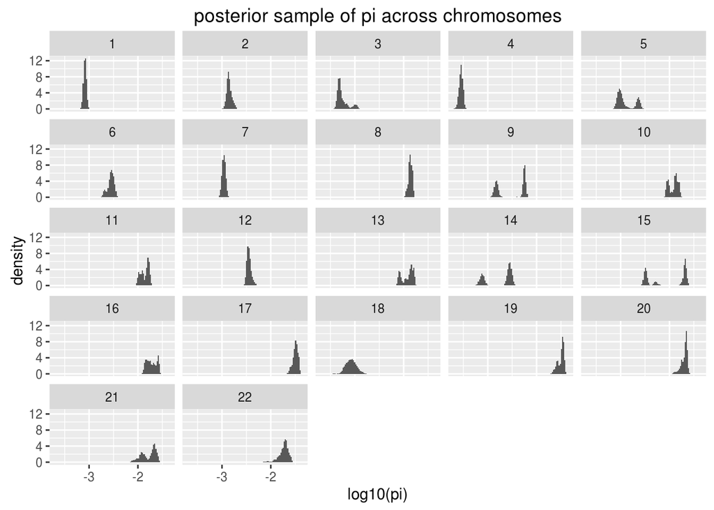

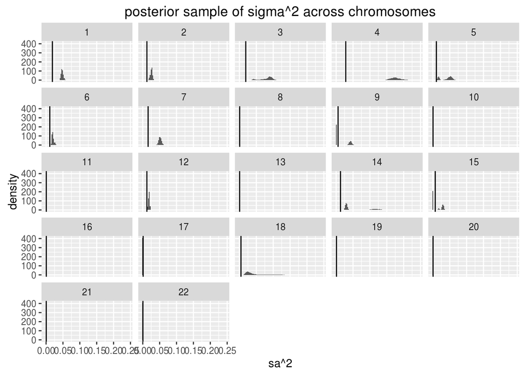

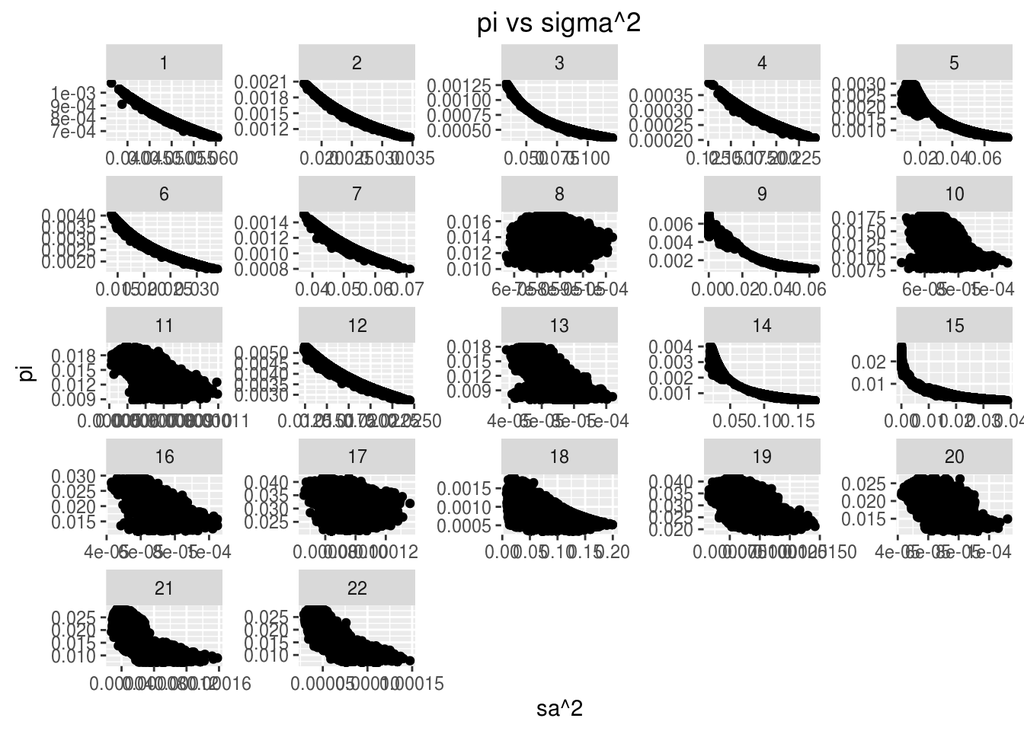

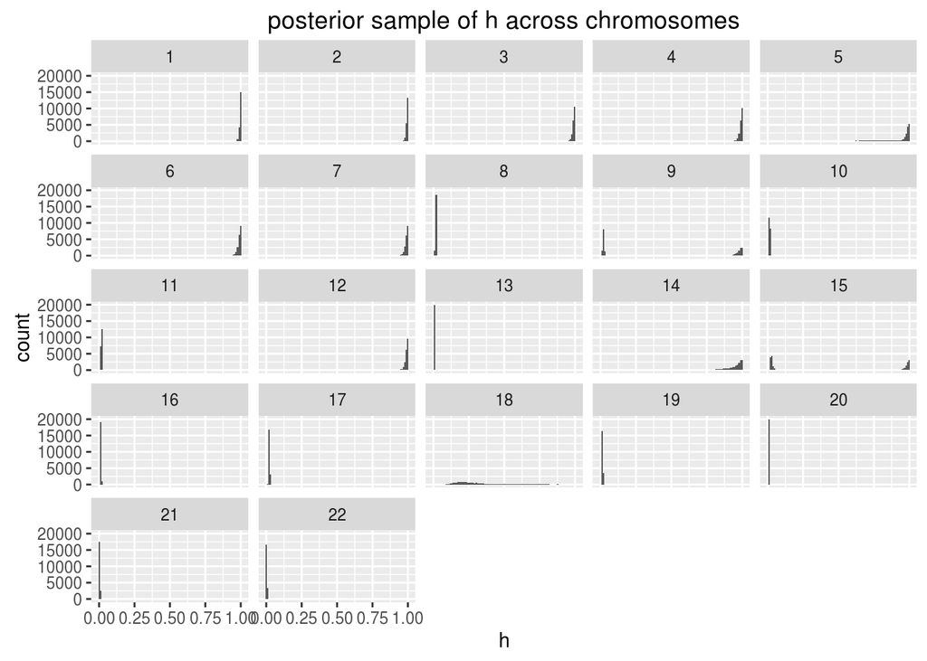

### Estimating $pi$ and $sigma^2$

For a first pass, we’ll try to use the standard spike and slab, per chromosome, and compare that to what RSS.

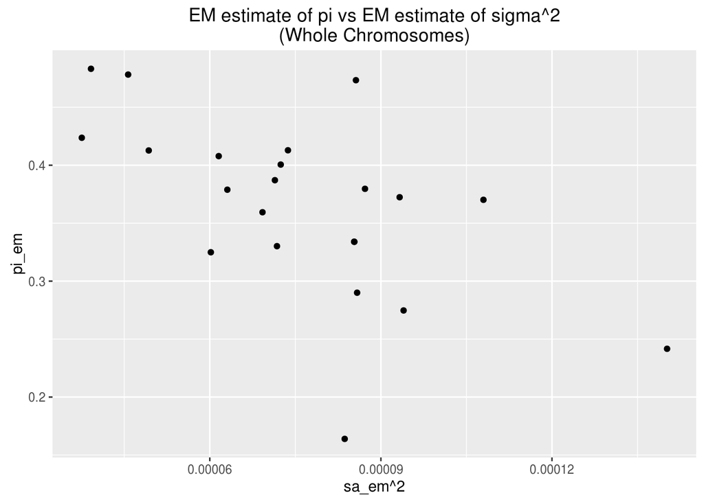

```r
wgwasem <- group_by(posdf,chrom) %>% do(par=squarem(exp(c(runif(1,log(1/length(.$se)),0),runif(1))),
                                     fixptfn = sslab_em,bh=.$betahat,
                                     si=.$se)$par) %>% summarise(pi_em=par[1],sa_em=par[2],chrom=chrom[1])

ggplot(wgwasem,aes(x=sa_em^2,y=pi_em))+geom_point()+ggtitle("EM estimate of pi vs EM estimate of sigma^2\n(Whole Chromosomes)")
```

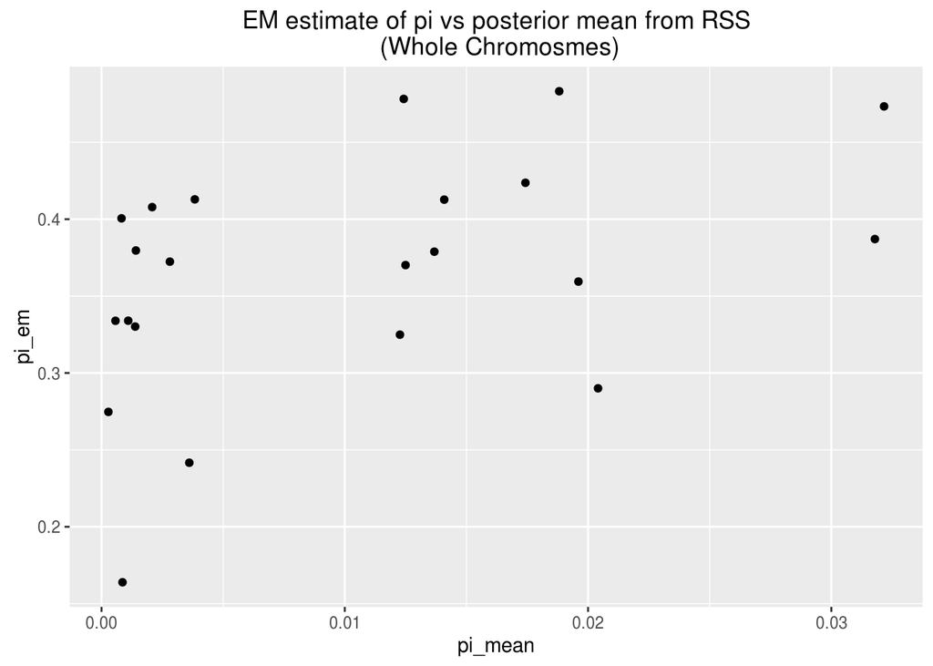

```r
inner_join(wgwasem,samsum) %>% ggplot(aes(x=pi_mean,y=pi_em))+geom_point()+ggtitle("EM estimate of pi vs posterior mean from RSS\n (Whole Chromosmes)")
```

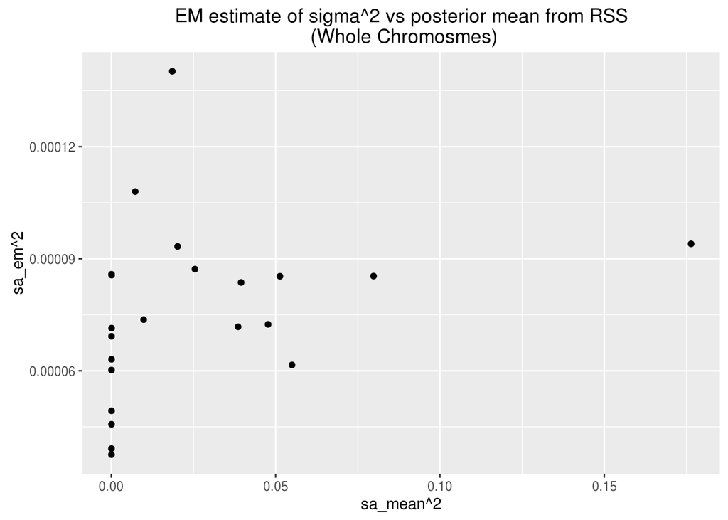

```r
inner_join(wgwasem,samsum) %>% ggplot(aes(x=sa_mean^2,y=sa_em^2))+geom_point()+ggtitle("EM estimate of sigma^2 vs posterior mean from RSS\n (Whole Chromosmes)")
```

### Estimation with an independent SNP set

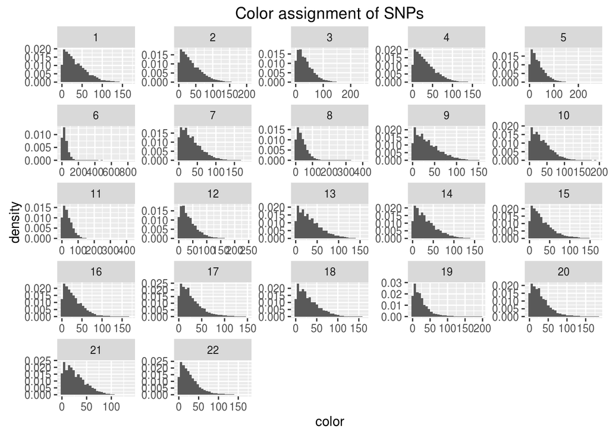

```r
ggplot(colordf)+geom_histogram(aes(x=color,..density..))+facet_wrap(~chrom,scales = "free")+ggtitle("Color assignment of SNPs")
```

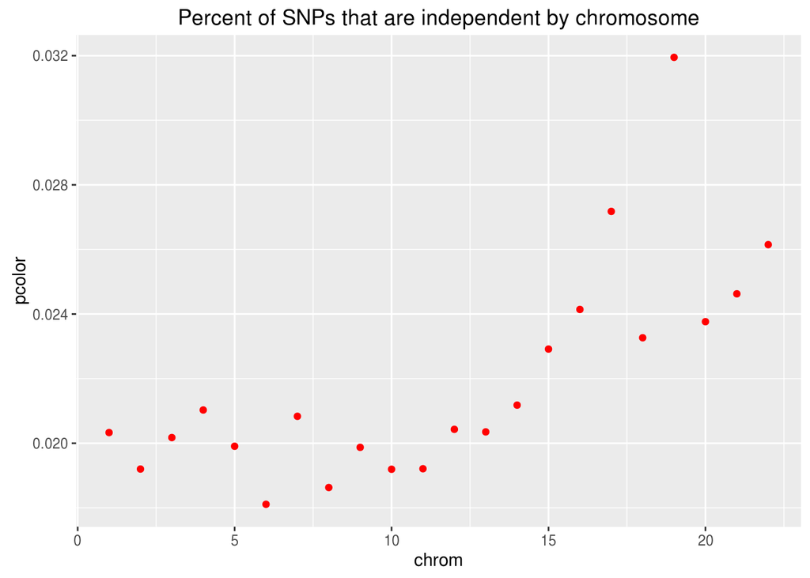

```r
group_by(colordf,chrom) %>% summarise(tot=n(),pcolor=sum(color==0)/tot) %>% ggplot()+geom_point(aes(x=chrom,y=pcolor),col="red")+ggtitle("Percent of SNPs that are independent by chromosome")
```

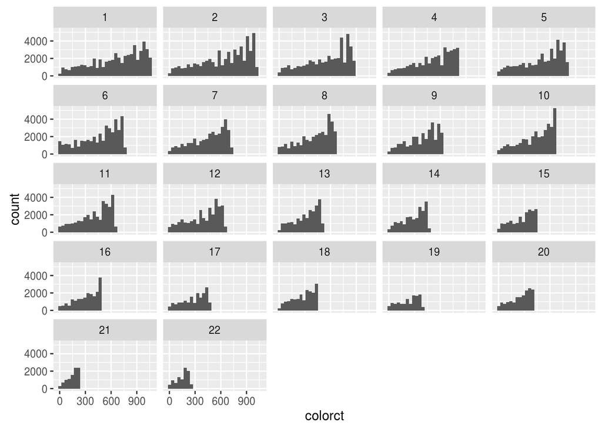

```r
colordf <- group_by(colordf,chrom,color) %>% mutate(colorct=n()) %>% ungroup()
ggplot(colordf)+geom_histogram(aes(x=colorct))+facet_wrap(~chrom)
```

```r
igwasem <- inner_join(posdf,colordf) %>% filter(colorct>300) %>% group_by(chrom,color) %>% do(par=fpiter(exp(c(runif(1,log(1/length(.$se)),0),runif(1))),
                                     fixptfn = sslab_em,bh=.$betahat,objfn = sslab_lik,
                                     si=.$se)$par,colorct=.$colorct[1]) %>% summarise(pi_em=par[1],sa_em=par[2],chrom=chrom[1],color=color[1],colorct=colorct[1])
```

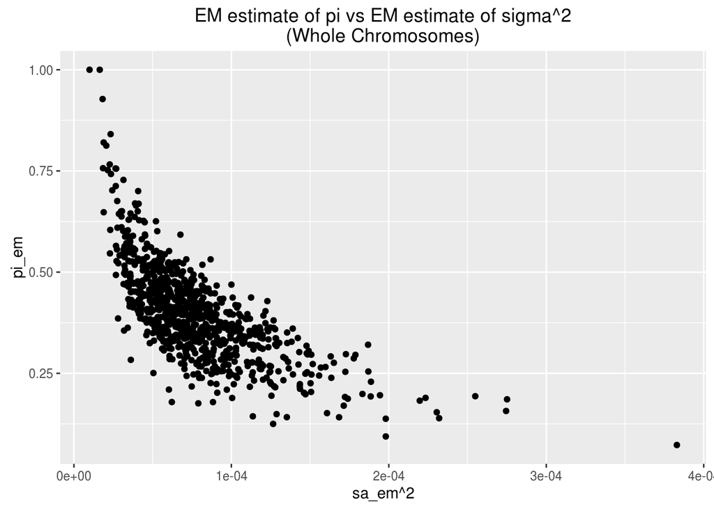

```r
ggplot(igwasem,aes(x=sa_em^2,y=pi_em))+geom_point()+ggtitle("EM estimate of pi vs EM estimate of sigma^2\n(Whole Chromosomes)")
```

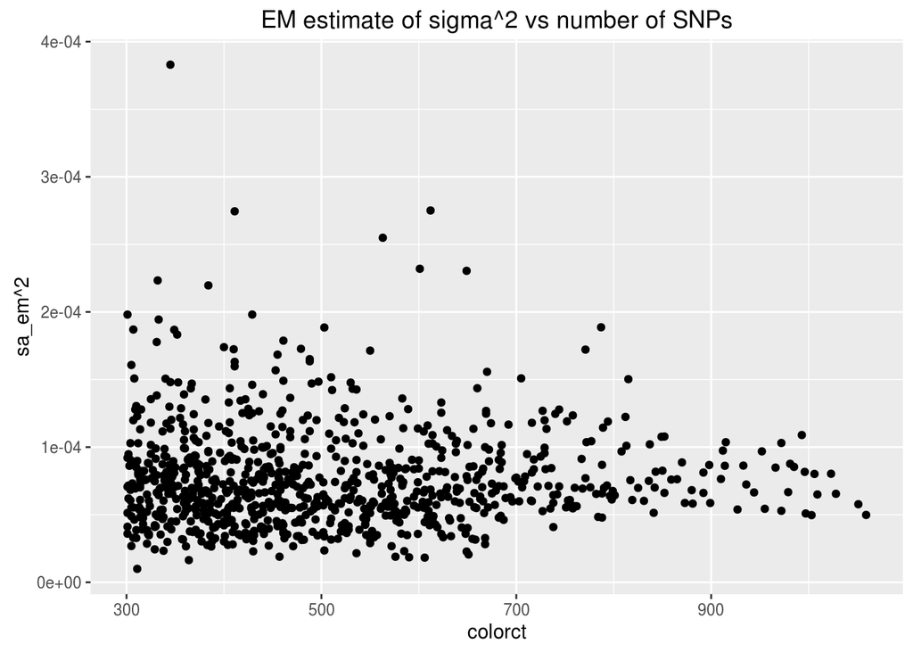

```r
ggplot(igwasem,aes(x=colorct,y=sa_em^2))+geom_point()+ggtitle("EM estimate of sigma^2 vs number of SNPs")
```

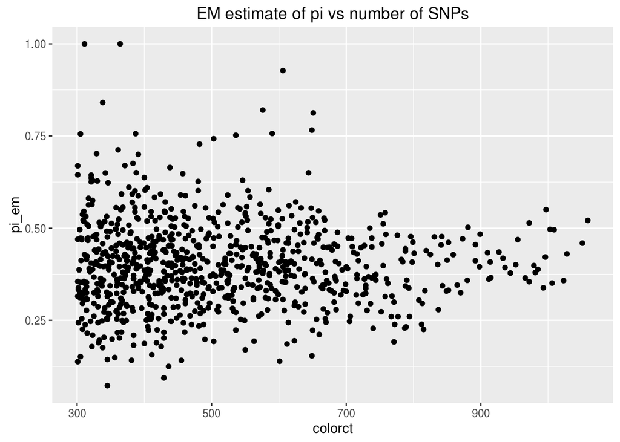

```r
ggplot(igwasem,aes(x=colorct,y=pi_em))+geom_point()+ggtitle("EM estimate of pi vs number of SNPs")
```

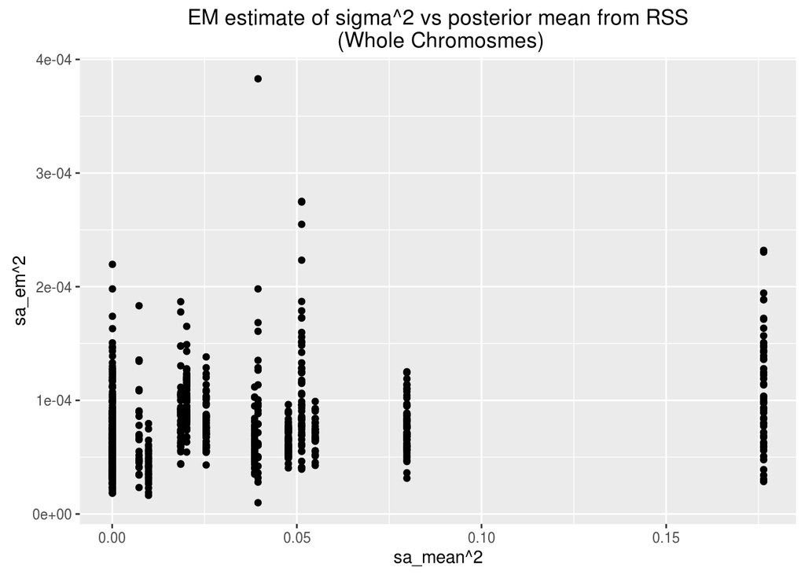

```r
inner_join(igwasem,samsum) %>% ggplot(aes(x=sa_mean^2,y=sa_em^2))+geom_point()+ggtitle("EM estimate of sigma^2 vs posterior mean from RSS\n (Whole Chromosmes)")
```

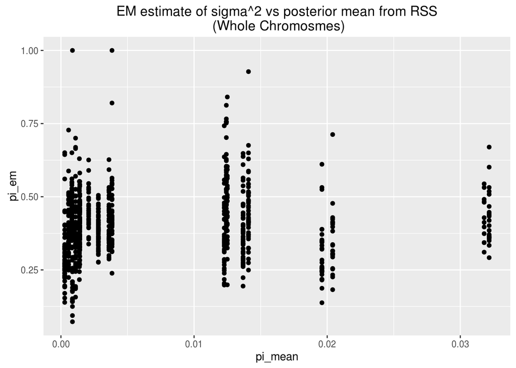

```r
inner_join(igwasem,samsum) %>% ggplot(aes(x=pi_mean,y=pi_em))+geom_point()+ggtitle("EM estimate of sigma^2 vs posterior mean from RSS\n (Whole Chromosmes)")
```

### Corrected Model

The next step is to use a corrected model, whereby we account for the distortion of signal by nearby causal SNPs.

```r
# sa <- filter(samsum,chrom==1)[["sa_mean"]]
# pi <- filter(samsum,chrom==1)[["pi_mean"]]
# tposdf <- read_h5_df(genofiles[1],"Legend")
# # ref_pos <- read_h5_df_l(LDfiles,group="LD_mat_ref")
#  LD_pos <- read_h5_df(LDfiles[1],group="LD_adj")
#   nlik <- adj_lik(rvec=LD_pos$LD,rowv =  LD_pos$rowid,
#                   colv=LD_pos$colid,betahat = tposdf$beta,se = tposdf$serr,sa = sa,pi = pi)
#   betavec <- tposdf$beta
#   sevec <- tposdf$serr
#   nLD_pos <- mutate(LD_pos,row_bh=betavec[rowid+1],col_bh=betavec[colid+1],
#                     row_se=sevec[rowid+1],col_se=sevec[colid+1])
#
#   tnLD_pos <- filter(nLD_pos,rowid==0|colid==0) %>% mutate(nlik=dnorm(row_bh,mean = 0,sd=sqrt(row_se^2*(1+LD^2/(col_se^2))*(sa^2)))) %>% summarise(slik=sum(nlik)/n())
#   rowposdf <- select(tposdf,rowid=ind,rowbetahat=beta,rowserr=serr)
#
#   head(tposdf)

# summary(LD_pos$LD)
# ggplot(LD_pos)+geom_histogram(aes(x=LD))
```